# RepData PeerAssessment1

First let’s load the personal activity dataset:

```r
activityData <- read.csv("activity.csv")
```

## What is mean total number of steps taken per day?

1- Make a histogram of the total number of steps taken each day

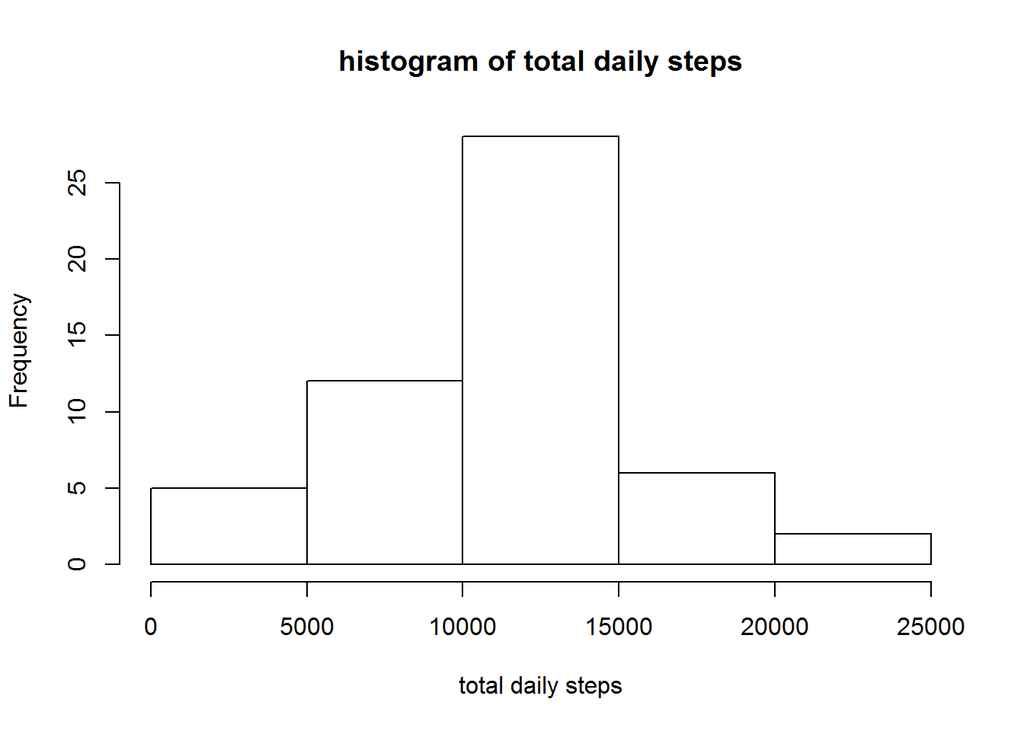

```r
totalDailySteps <- aggregate(steps ~ date, data = activityData, FUN = sum, na.rm = TRUE)
hist(totalDailySteps$steps, xlab = "total daily steps", main = "histogram of total daily steps")
```

2- Calculate and report the mean and median total number of steps taken per day

The **mean** total number of steps taken per day is **10,766.19**  
The **median** total number of steps taken per day is **10,765**

## What is the average daily activity pattern?

1- Make a time series plot (i.e. type = “l”) of the 5-minute interval (x-axis) and the average number of steps taken, averaged across all days (y-axis)

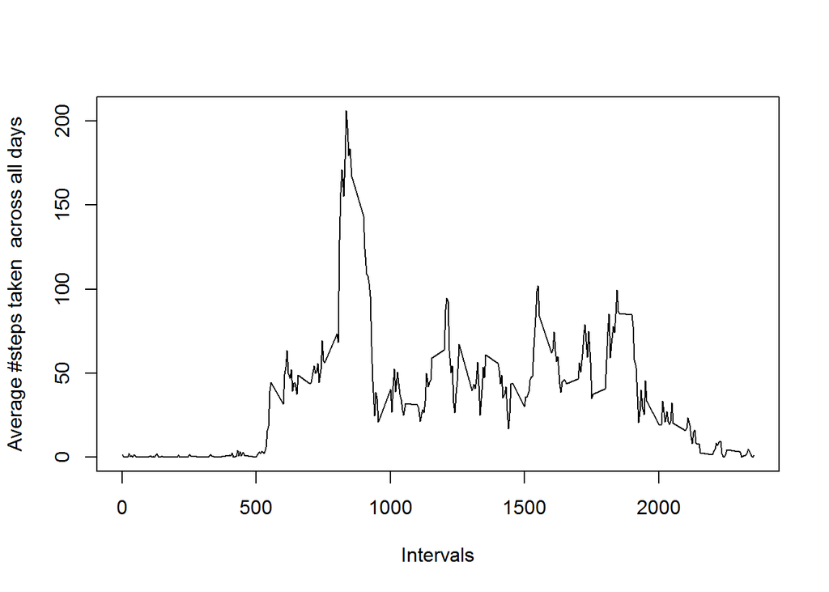

```r
stepsByInterval <- aggregate(steps ~ interval, data = activityData, FUN = mean, na.rm = TRUE)
plot(stepsByInterval$interval, stepsByInterval$steps, type = "l", xlab = "Intervals", ylab = "Average #steps taken  across all days")
```

2- Which 5-minute interval, on average across all the days in the dataset, contains the maximum number of steps?  
The 5-minute interval with the maximum number of steps is **835**

## Imputing missing values

1- Calculate and report the total number of missing values in the dataset (i.e. the total number of rows with NAs)  
The total number of rows with NAs is **2,304**

2- Devise a strategy for filling in all of the missing values in the dataset. The strategy does not need to be sophisticated. For example, you could use the mean/median for that day, or the mean for that 5-minute interval, etc.  
*I’ll be using the daily average number of steps to fill in the missing values*

3- Create a new dataset that is equal to the original dataset but with the missing data filled in.

```r
averageDailySteps <- aggregate(steps ~ date, data = activityData, FUN = mean)
names(averageDailySteps)[2] <- "DailystepsMean"
mergedData <- merge(activityData, averageDailySteps)
mergedData$steps[is.na(mergedData$steps)] <- mergedData$DailystepsMean[is.na(mergedData$steps)]
```

4- Make a histogram of the total number of steps taken each day and Calculate and report the mean and median total number of steps taken per day. Do these values differ from the estimates from the first part of the assignment? What is the impact of imputing missing data on the estimates of the total daily number of steps?

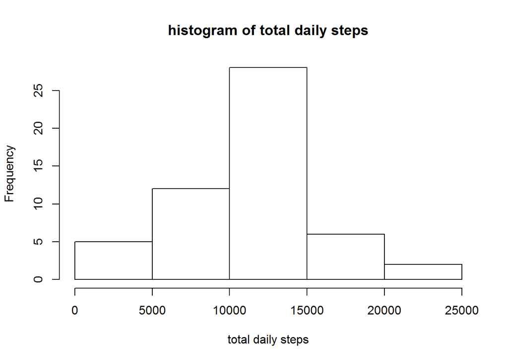

```r
new_totalDailySteps <- aggregate(steps ~ date, data = mergedData, FUN = sum)
hist(new_totalDailySteps$steps, xlab = "total daily steps", main = "histogram of total daily steps")
```

New mean total number of steps taken per day is **10,766.19**  
New median total number of steps taken per day is **10,765**

*mean and median of the imputed data are the same as the original dataset*

## Are there differences in activity patterns between weekdays and weekends?

1- Create a new factor variable in the dataset with two levels – “weekday” and “weekend” indicating whether a given date is a weekday or weekend day.

```r
wd <- c('Monday', 'Tuesday', 'Wednesday', 'Thursday', 'Friday')
mergedData$Weekday <- factor(weekdays(as.Date(mergedData$date)) %in% wd, levels=c(FALSE, TRUE), labels=c('weekend', 'weekday'))
```

2- Make a panel plot containing a time series plot (i.e. type = “l”) of the 5-minute interval (x-axis) and the average number of steps taken, averaged across all weekday days or weekend days (y-axis)

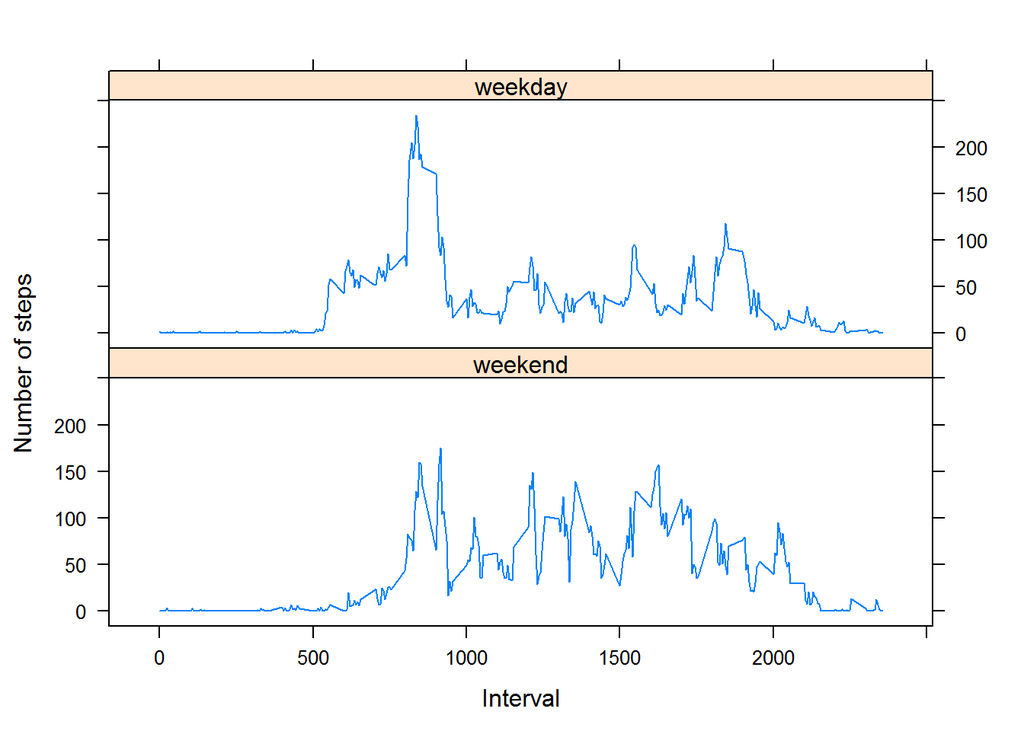

```r
library(lattice)
c <- aggregate(steps ~ interval + Weekday, data = mergedData, FUN = mean)
xyplot(steps ~ interval | Weekday, data = c, type = "l", layout = c(1,2), ylab = "Number of steps", xlab = "Interval")
```